# How to Mizer - how to parametrise a Mizer model

Julia L. Blanchard, Ken H. Andersen, Gustav Delius, Romain Forestier

2021-06-11

# Beginner level tutorial - how to parameterise a Mizer model

In this tutorial you will learn

- What type of data is needed to parametrise a Mizer model
- How to convert raw data into a `mizerParams` object
- Check the several assumptions you are making about your parameters
- Explore the model for the first time with your own data set

## Step 1 - What data are typically needed to parameterise a mizer model?

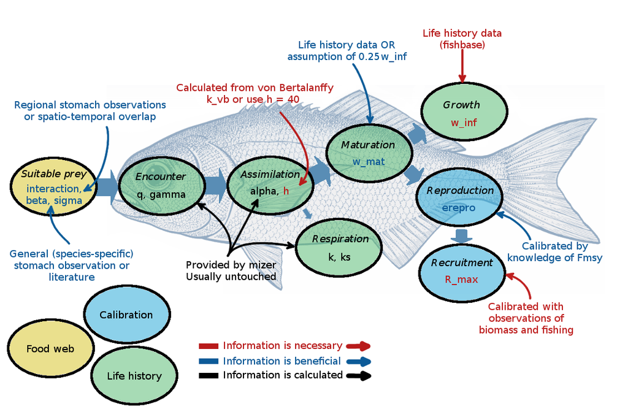

Figure 1: Illustration of the parameters needed (green boxes) and calibrated (blue boxes) by Mizer. The need for data is hierarchical: a model can be setup and calibrated with the information in red: knowledge of the asymptotic size and observations of biomass and fishing. The calibration can be refined by adding further information in life history parameters and by using knowledge of Fmsy to calibrate the reproductive efficiency (blue). Additional refinement can be done by specifying the interaction matrix, theta (blue). Other parameters can be adjusted but they are rarely known accurately on a species-by-species basis (black).

parameters’ description

| parameter | description |
| --- | --- |
| w_inf | asymptotic weigth |
| w_mat | maturation weight (determines when 50% of the population has matured using a sigmoid function) |
| beta | preferred predator/prey mass ratio |
| sigma | width of the feeding kernel |
| R_max | Beverton-Holt density dependence parameter |
| k_vb | von Bertalanffy growth parameter |
| l25 | length at 25% catch |
| l50 | length at 50% catch |
| a | coefficient for age to size conversion |
| b | constant for age to size conversion |
| catchability | fisheries efficiency |
| h | maximum intake rate |
| k | metabolism constant |
| ks | metabolism coefficient |
| z0 | background mortality coefficient |
| gamma | search volume (obtained from beta and sigma) |
| w_mat25 | weight at which 25% of individuals are mature |
| erepro | reproductive output scalar |

The multispecies model in mizer allows one to resolve species-specific differences in life history and feeding parameters that are important for modelling particular ecosystems.

Let’s start with the minimal amount of information needed to run a mizer model.

First you are going to need a data frame of species specific parameters to input into the `newMultispeciesParams()` function. This function requires at least three columns of parameters:

- species name (`species`)
- asymptotic weight (`w_inf`)
- maximum intake rate (`h`) or von Bertalanffy growth parameter (`k_vb`)

### Von Bertalanffy Growth Function

> The growth curve of a fish is commonly reported as a von Bertalanffy growth curve. The von Bertalanffy curve describes the length of a fish as a function of two parameters; the asymptotic length $L_\infty$ and the von Bertalanffy growth coefficient $K$ (`k_vb` in Mizer):
> $$L_{(t)} = L_\infty (1-e^{-Kt})$$
> where $t$ is the age. $L_\infty$ represents the asymptotic length and $1/k_vb$ is approximately the age at maturation. Mizer, however, uses two two other parameters, $W_\infty$ and $h$ (`w_inf` in Mizer), where $W_\infty$ represents the asymptotic weight and $h$ the size-scale maximum consumption rate. Fortunately, the two sets of parameters are related, and one can derive $h$ and $W_\infty$ from von Bertalanffy $K$ and $L_\infty$.

> The parameter $h$ represents the maximum consumption rate of a fish, scaled by size. If we assume that stomach fullness (the feeding level) is that same for fish of all sizes, then $h$ is related to the coefficient of the initial growth rate $A$ (blue slanted dashed line) as $h \approx 4A$. The value of $h$ varies between 4 – 400, with a geometric mean around 22 g$^{-0.25}$/year across all fish species (Andersen 2019, chap. 2 and 11). A more precise estimate can be obtained from von Bertalanffy $K$ and $L_\infty$ as: $h \approx 4.75 K\cdot L_\infty^{0.75}$ (with $K$ given in 1/years and $L_\infty$ in cm).

The data frame is arranged as species by parameter, so each column of the parameter data frame is a parameter and each row has the values of the parameters for one of the species in the model.

You will also need an interaction matrix that defines the overlapping interaction between each species (default is set to 1).

### Interaction matrix

> Such matrix determines the availability of a prey to a predator. Values ranges from 0 to 1 and are assigned to each combination of predator/prey in the ecosystem (canibalism included). 1 is translated by full availability of a prey to a predator whereas 0 is none. The interaction value may vary due to different time overlap between prey and predator (e.g. diurne and nocturne animals) or different spatial overlap (e.g. depths and biomes).

All other parameters either have default values or will be calculated from the supplied parameters.

Let’s start with a small made up example assuming we have already found some parameters from FishBase or the literature. Here we consider two interacting species and a background resource spectrum (we will come back to this). Using the North Sea as an example, let’s start with the iconic Atlantic Cod and a key local prey species Sandeel.

To set up this model we can look on Fishbase (www.fishbase.se or use the `rfishbase` package) to find the aymptotic weights of these two species. A search on fishbase reveals some parameters from empirical von Bertalanffy growth curves which can be used to set up the life history parameters - `w_inf` and `k_vb`. Often von Bertalanffy relationships are based on length and not weight. The length parameters can be converted to weight using length-weight regressions

### Length-weight regression

> The asymptotic length and weight are related as:
> $$W_\infty = a \cdot L_\infty^b$$
> Species-specific conversion coefficients $a$ and $b$ are found in Froese (2006). Reasonable general values are: $a = 0.01\ \mathrm{g/cm}^{-3}$ and $b = 3$.

We find an asymptotic length of 132 cm and k_vb of 0.2/year for cod in the North Sea here:https://www.fishbase.se/popdyn/PopGrowthList.php?ID=69&GenusName=Gadus&SpeciesName=morhua&fc=183

We then need to convert these asymptotic lengths to weights using length-weight regression parameters, which also can be found on fishbase or in the literature.

For cod the estimation is $w_{inf} = 24600$ g https://www.fishbase.se/popdyn/LWRelationshipList.php?ID=69&GenusName=Gadus&SpeciesName=morhua&fc=183

For sandeel the estimation is $w_{inf} = 22.83$ g https://www.fishbase.se/popdyn/LWRelationshipList.php?ID=37&GenusName=Ammodytes&SpeciesName=marinus&fc=402

If `w_inf` or `l_inf` are not available you could use maximum observed sizes. These values are often systematically larger than estimates of asymptotic weight, and we recommend you check the literature or size-at-age data for your system to check reliability of fishbase estimates.

We also know from the literature that the preferred predator-prey mass ratio for Cod is approximately 100 and we might guess that it is approximately 10000 for Sandeel as they feed on prey much smaller than themselves.

### Predator:prey mass ratio PPMR

> The PPMR gives an indication of the prey size predators preferably feed upon. A small PPMR means that the predator feeds on prey close to their size (e.g PPMR of 10 equal a prey 10 times smaller than the predator) whereas a large PPMR means that the predator feeds on prey considerably smaller than their own size (e.g baleen whales). The preferred PPMR in Mizer is noted `beta`.

For simplicity, we will assume defaults for all other parameters and that both species occur in the same environmenta throughout their lives (interaction matrix = 1).

```r
smallExample <- data.frame("species" = c("sandeel","cod"),"w_inf" = c(23,24600), "k_vb" = c(0.1,0.2),"beta" = c(10000,100))
kable(smallExample, caption = "species' parameters")
```

species’ parameters

| species | w_inf | k_vb | beta |
| --- | --- | --- | --- |
| sandeel | 23 | 0.1 | 10000 |
| cod | 24600 | 0.2 | 100 |

```r
smallInter <- matrix(c(1,1,1,1),ncol = 2, dimnames = list(smallExample$species,smallExample$species))
kable(smallInter, caption = "species' interactions")
```

species’ interactions

|  | sandeel | cod |
| --- | --- | --- |
| sandeel | 1 | 1 |
| cod | 1 | 1 |

The `smallExample` shows the format of the data frame for the species parameters and the `smallInter` shows the format of the interaction matrix. Both of these are required as inputs for creating a `mizerParams` object. Many mizer users will collect this information in a spreadsheet prior to reading in the data into mizer.

To illustrate this next step we will use pre-existing set of species’ specific parameters for a previously published North Sea model, that used more detailed fisheries dependent and independent data to calculate species parameters.

These files are availalble in the “How to Mizer” GitHub repository as shown below.

```r
nsParams <- read.csv("../data/nsparams0.csv")
inter <- readRDS("../data/interNS.rds")
# more information on how to set this up is here:
#https://sizespectrum.org/mizer/articles/a_multispecies_model_of_the_north_sea.html
```

North Sea species’ parameters

| species | w_inf | w_mat | beta | sigma | k_vb | sel_func | l25 | l50 | a | b | catchability | gear |
| --- | --- | --- | --- | --- | --- | --- | --- | --- | --- | --- | --- | --- |
| Sprat | 33.0 | 13 | 51076 | 0.8 | 0.681 | sigmoid_length | 7.6 | 8.1 | 0.007 | 3.014 | 1.2953333 | sigmoid_gear |
| Sandeel | 36.0 | 4 | 398849 | 1.9 | 1.000 | sigmoid_length | 9.8 | 11.8 | 0.001 | 3.320 | 0.0651055 | sigmoid_gear |
| N.pout | 100.0 | 23 | 22 | 1.5 | 0.849 | sigmoid_length | 8.7 | 12.2 | 0.009 | 2.941 | 0.3138000 | sigmoid_gear |
| Dab | 324.0 | 21 | 191 | 1.9 | 0.536 | sigmoid_length | 11.5 | 17.0 | 0.010 | 2.986 | 0.9780000 | sigmoid_gear |
| Herring | 334.0 | 99 | 280540 | 3.2 | 0.606 | sigmoid_length | 10.1 | 20.8 | 0.002 | 3.429 | 0.1815000 | sigmoid_gear |
| Gurnard | 668.0 | 39 | 283 | 1.8 | 0.266 | sigmoid_length | 19.8 | 29.0 | 0.004 | 3.198 | 0.4625057 | sigmoid_gear |
| Sole | 866.0 | 78 | 381 | 1.9 | 0.284 | sigmoid_length | 16.4 | 25.8 | 0.008 | 3.019 | 0.3738333 | sigmoid_gear |
| Whiting | 1192.0 | 75 | 22 | 1.5 | 0.323 | sigmoid_length | 19.8 | 29.0 | 0.006 | 3.080 | 0.2426667 | sigmoid_gear |
| Plaice | 2976.0 | 105 | 113 | 1.6 | 0.122 | sigmoid_length | 11.5 | 17.0 | 0.007 | 3.101 | 0.1848333 | sigmoid_gear |
| Haddock | 4316.5 | 165 | 558 | 2.1 | 0.271 | sigmoid_length | 19.1 | 24.3 | 0.005 | 3.160 | 0.3015000 | sigmoid_gear |
| Saithe | 39658.6 | 1076 | 40 | 1.1 | 0.175 | sigmoid_length | 35.3 | 43.6 | 0.007 | 3.075 | 0.3930000 | sigmoid_gear |
| Cod | 39851.3 | 1606 | 66 | 1.3 | 0.216 | sigmoid_length | 13.2 | 22.9 | 0.005 | 3.173 | 0.2666675 | sigmoid_gear |

North Sea interaction matrix

|  | Sprat | Sandeel | N.pout | Dab | Herring | Gurnard | Sole | Whiting | Plaice | Haddock | Saithe | Cod |
| --- | --- | --- | --- | --- | --- | --- | --- | --- | --- | --- | --- | --- |
| Sprat | 0.7291292 | 0.0340844 | 0.0635452 | 0.3624155 | 0.2741698 | 0.1751558 | 0.2979556 | 0.2652592 | 0.3706598 | 0.0813555 | 0.0168132 | 0.3375797 |
| Sandeel | 0.0340844 | 0.6811988 | 0.0489243 | 0.0973666 | 0.0588821 | 0.0599265 | 0.0602086 | 0.0751001 | 0.0780185 | 0.0939573 | 0.0160902 | 0.0994345 |
| N.pout | 0.0635452 | 0.0489243 | 0.7966043 | 0.0908880 | 0.2975507 | 0.3062414 | 0.0167902 | 0.2998989 | 0.0785582 | 0.5491755 | 0.2949894 | 0.3250226 |
| Dab | 0.3624155 | 0.0973666 | 0.0908880 | 0.8081777 | 0.2896396 | 0.2204120 | 0.3804746 | 0.3338973 | 0.5649221 | 0.1316806 | 0.0313820 | 0.4164780 |
| Herring | 0.2741698 | 0.0588821 | 0.2975507 | 0.2896396 | 0.6589010 | 0.2751063 | 0.2001414 | 0.3737393 | 0.2779187 | 0.3483547 | 0.1262059 | 0.4047793 |
| Gurnard | 0.1751558 | 0.0599265 | 0.3062414 | 0.2204120 | 0.2751063 | 0.8801050 | 0.1067789 | 0.3710990 | 0.1649212 | 0.3573544 | 0.1235199 | 0.3518328 |
| Sole | 0.2979556 | 0.0602086 | 0.0167902 | 0.3804746 | 0.2001414 | 0.1067789 | 0.7155805 | 0.1922746 | 0.3913732 | 0.0344780 | 0.0124205 | 0.2576123 |
| Whiting | 0.2652592 | 0.0751001 | 0.2998989 | 0.3338973 | 0.3737393 | 0.3710990 | 0.1922746 | 0.7092823 | 0.2950381 | 0.3916479 | 0.1022817 | 0.4406088 |
| Plaice | 0.3706598 | 0.0780185 | 0.0785582 | 0.5649221 | 0.2779187 | 0.1649212 | 0.3913732 | 0.2950381 | 0.7192239 | 0.1124851 | 0.0329494 | 0.3504367 |
| Haddock | 0.0813555 | 0.0939573 | 0.5491755 | 0.1316806 | 0.3483547 | 0.3573544 | 0.0344780 | 0.3916479 | 0.1124851 | 0.8583072 | 0.2616747 | 0.3957734 |
| Saithe | 0.0168132 | 0.0160902 | 0.2949894 | 0.0313820 | 0.1262059 | 0.1235199 | 0.0124205 | 0.1022817 | 0.0329494 | 0.2616747 | 0.6638355 | 0.2089450 |
| Cod | 0.3375797 | 0.0994345 | 0.3250226 | 0.4164780 | 0.4047793 | 0.3518328 | 0.2576123 | 0.4406088 | 0.3504367 | 0.3957734 | 0.2089450 | 0.7865471 |

The second type of data you are going to need is a data set of catch and/or spawning stock biomass ($SSB$) of the selected species, so you can compare the model output’s to real data. The fisheries time-series of the North Sea are also available in this repository. We will use these data later in our second tutorial on calibration.

Because the North Sea is heavily fished we also need information on fishing intensity and other parameters have been entered into the species parameter file that relate to the type of fishing gear selectivity (which is assumed to be species-specific).

In mizer, fishing mortality rates at size for each gear are calculated as

$$F = catchability\cdot selectivity \cdot effort$$

Selectivity is determined using the `l_25`, `l_50`, and `sel_func` parameters but simpler appraches can also be used. See https://sizespectrum.org/mizer/reference/setFishing.html One effort is set during the simulation for each gear in the ecosystem, which is determined by `gear`. Finally, catchability is `catchability`.

For the North Sea we assumed $catchability.effort$ could be estimated from the fishing mortality rates of fully selected sizes/ages of fish from single-species stock assessments. The following .csv are extracted from the ICES stock assessment database using “data/getICESFishdata_param.R”. Fishing mortality data is averaged over 2014-2019 as it is a relatively stable period in catches and has the maximum amount of data across all species concerned.

```r
# fisheries mortality F
fMat <- read.csv("../data/fmat.csv")

# Sandeel and Cod have multiple data base so average their F and weighting by SSB
# extrapolating Gurnard data from Dab (similar life history)
fMatWeighted <- readRDS("../data/FmatWeightedInterpolated.rds")

# read in time-averaged  catches
catchAvg <-read.csv("../data/time-averaged-catches.csv") # catches are estimated from fMatW

# ssb
ssbAvg <- read.csv("../data/time-averaged-SSB.csv")
```

## Step 2 - How to convert the data into a valid `mizerParams` object

In this section you will:

- Learn to format raw data into a Mizer compatible format

Inputing the previous data frame and interaction matrix into the `newMultispeciesParams()` function output a fully fleshed `mizerParams` object

```r
param <- newMultispeciesParams(smallExample,smallInter)
```

```
## Note: No h provided for some species, so using f0 and k_vb to calculate it.
```

```
## Note: Because you have n != p, the default value is not very good.
```

```
## Note: No ks column so calculating from critical feeding level.
```

```
## Note: Using z0 = z0pre * w_inf ^ z0exp for missing z0 values.
```

```
## Note: Using f0, h, lambda, kappa and the predation kernel to calculate gamma.
```

```r
param@species_params
```

```
##         species w_inf k_vb  beta   w_mat w_min alpha interaction_resource
## sandeel sandeel    23  0.1 10000    5.75 0.001   0.6                    1
## cod         cod 24600  0.2   100 6150.00 0.001   0.6                    1
##                 n   p         q pred_kernel_type sigma         h k        ks
## sandeel 0.6666667 0.7 0.7166667        lognormal     2  2.126856 0 0.2407671
## cod     0.6666667 0.7 0.7166667        lognormal     2 45.821729 0 4.1110890
##                 z0        gamma     w_mat25 m erepro R_max
## sandeel 0.21098033 3.661644e-12    5.151761 1      1   Inf
## cod     0.02063033 1.002286e-10 5510.144528 1      1   Inf
```

You can see that mizer has estimated several missing parameters. [Go through each of these and take a look at figure 1]

Let’s do the same for our North Sea data set and look at what parameters we can find in the `mizerParams` object:

```r
params_uncalibrated <- newMultispeciesParams(nsParams, inter, kappa = 1e11)
```

```
## Note: No h provided for some species, so using f0 and k_vb to calculate it.
```

```
## Note: Because you have n != p, the default value is not very good.
```

```
## Note: No ks column so calculating from critical feeding level.
```

```
## Note: Using z0 = z0pre * w_inf ^ z0exp for missing z0 values.
```

```
## Note: Using f0, h, lambda, kappa and the predation kernel to calculate gamma.
```

You will note that in the case of the North Sea, we provide another parameter `kappa`. `kappa` sets the carrying capacity of the ecosystem and is set to reflect the entire volume of the North Sea - hence the very large `kappa` value.

### Background resource spectrum

> In Mizer, a background resource spectrum is simulated to represent all the food sources that are not explicilty modelled as fish. It is especially useful to feed small-sized fish that are not piscivores. The carrying capacity of the background spectrum is determined by `kappa` and its regeneration rate by `r_pp`. High `kappa` implies more food and therefore faster growth rate and/or higher sustainable fish biomass.

```r
# small edits to the mizerParam object

params_uncalibrated@species_params$erepro <- .01 # default is 1
params_uncalibrated@linecolour[1:12] <- viridis(dim(params_uncalibrated@species_params)[1]) # color gradient of asymptotic sizes

#  Add other params for info
#  param$Volumecubicmetres=5.5e13    #unit of volume. Here total volume of North sea is used (Andersen & Ursin 1977)
```

mizerParams object

| species | w_inf | w_mat | beta | sigma | k_vb | l25 | l50 | a | b | catchability | h | ks | z0 | gamma | erepro | R_max |
| --- | --- | --- | --- | --- | --- | --- | --- | --- | --- | --- | --- | --- | --- | --- | --- | --- |
| Sprat | 33.0 | 13 | 51076 | 0.8 | 0.681 | 7.6 | 8.1 | 0.007 | 3.014 | 1.2953333 | 14.46675 | 1.593753 | 0.1870596 | 0 | 0.01 | Inf |
| Sandeel | 36.0 | 4 | 398849 | 1.9 | 1.000 | 9.8 | 11.8 | 0.001 | 3.320 | 0.0651055 | 25.62741 | 2.936414 | 0.1817121 | 0 | 0.01 | Inf |
| N.pout | 100.0 | 23 | 22 | 1.5 | 0.849 | 8.7 | 12.2 | 0.009 | 2.941 | 0.3138000 | 31.20422 | 3.372902 | 0.1292661 | 0 | 0.01 | Inf |
| Dab | 324.0 | 21 | 191 | 1.9 | 0.536 | 11.5 | 17.0 | 0.010 | 2.986 | 0.9780000 | 34.87720 | 3.781368 | 0.0873580 | 0 | 0.01 | Inf |
| Herring | 334.0 | 99 | 280540 | 3.2 | 0.606 | 10.1 | 20.8 | 0.002 | 3.429 | 0.1815000 | 28.36363 | 2.920263 | 0.0864774 | 0 | 0.01 | Inf |
| Gurnard | 668.0 | 39 | 283 | 1.8 | 0.266 | 19.8 | 29.0 | 0.004 | 3.198 | 0.4625057 | 20.64990 | 2.193126 | 0.0686371 | 0 | 0.01 | Inf |
| Sole | 866.0 | 78 | 381 | 1.9 | 0.284 | 16.4 | 25.8 | 0.008 | 3.019 | 0.3738333 | 24.73805 | 2.567302 | 0.0629475 | 0 | 0.01 | Inf |
| Whiting | 1192.0 | 75 | 22 | 1.5 | 0.323 | 19.8 | 29.0 | 0.006 | 3.080 | 0.2426667 | 31.77220 | 3.301616 | 0.0565882 | 0 | 0.01 | Inf |
| Plaice | 2976.0 | 105 | 113 | 1.6 | 0.122 | 11.5 | 17.0 | 0.007 | 3.101 | 0.1848333 | 16.94072 | 1.740765 | 0.0417132 | 0 | 0.01 | Inf |
| Haddock | 4316.5 | 165 | 558 | 2.1 | 0.271 | 19.1 | 24.3 | 0.005 | 3.160 | 0.3015000 | 41.46028 | 4.196598 | 0.0368503 | 0 | 0.01 | Inf |
| Saithe | 39658.6 | 1076 | 40 | 1.1 | 0.175 | 35.3 | 43.6 | 0.007 | 3.075 | 0.3930000 | 59.95343 | 5.700788 | 0.0175943 | 0 | 0.01 | Inf |
| Cod | 39851.3 | 1606 | 66 | 1.3 | 0.216 | 13.2 | 22.9 | 0.005 | 3.173 | 0.2666675 | 69.40226 | 6.511735 | 0.0175659 | 0 | 0.01 | Inf |

## Step 3 - Running and exploring the model for the first time to check coexistence (e.g. first guess)

In this section you will:

- Try to get coexistence between your species manually

First, let’s use the `project()` function with our `mizerParams` object to project in time our initial ecosystem and see if species manage to coexist together. We set `effort=1` as we already estimated $catchability.effort$ in the `catchability` column of the species data frame.

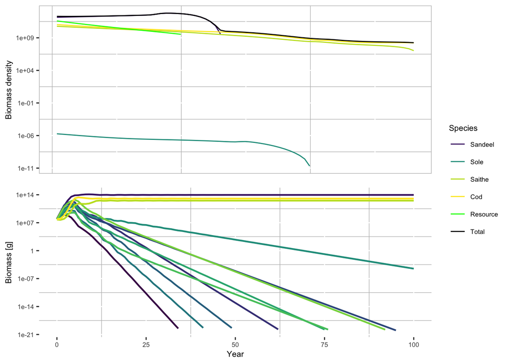

```r
sim_uncalibrated <- project(params_uncalibrated, effort = 1)
plotCalibration(sim_uncalibrated, stage = 1)
```

The top panel shows the different species size spectrum at the last time step of the simulation while the bottom panel shows the abundance per species through time.

### Stock recruitment relationship

> In Mizer, density dependence is modelled as a stock-recruitment relationship (SRR). The default is such that the recruitment approaches a maximum as the independendent reproduction rate (RDI) increases (similar to a Holling type II function response).
> $$RDD = R_{max}\frac{RDI}{RDI + R_{max}}$$
> RDD is the dependent reproduction rate that will determine the recruitement per species in the model.

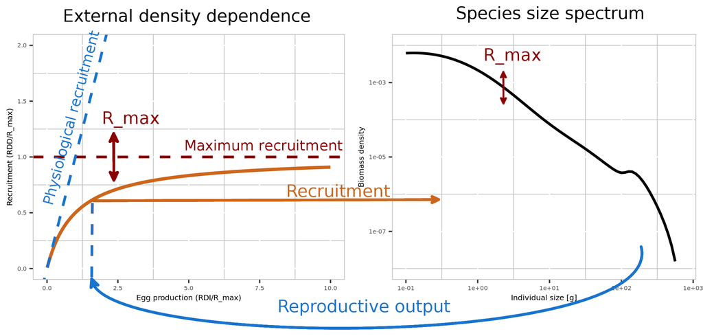

Figure 2: Illustration of the interplay between the reproductive output and the external density dependence. The model simulates a size spectrum of each species (right). From that spectrum it calculates the reproductive output (blue arrow). The reproductive output is reduced by imposing an external density dependence in the form of a stock recruitment relationship (left panel; orange line). The recruitment then determines the flow of new recruits into the size spectrum. The simulation continues until the size spectrum reaches an equilibrium (which may be a dynamic equilibrium). Changing Rmax up or down by a factor results in a change up or down of the spectrum by the same factor. Rmax therefore functions as the central parameter that adjusts the total biomass of a species.

To get coexistence one needs to guess reasonable $R_{max}$ values which will stop out-competition from a few species. We assume that a the density dependence is going to be posively related to body size, meaning that large individuals will have a stronger density-dependence applied to them (and therefore a lower $R_{max}$ value). Let’s start again and set some guessed `R_max` values.

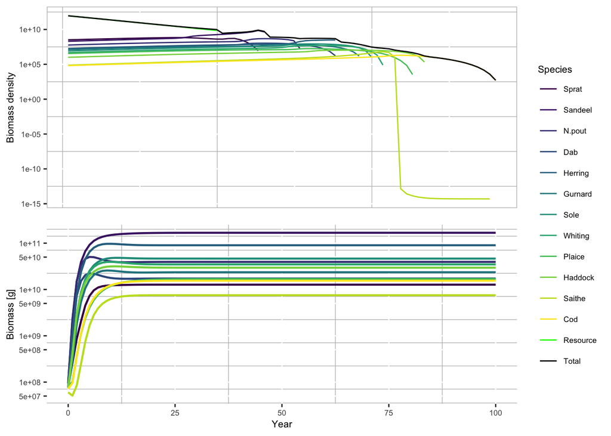

```r
params_guessed <- params_uncalibrated
# penalise the large species with higher density dependence
params_guessed@species_params$R_max <- params_guessed@resource_params$kappa*params_guessed@species_params$w_inf^-1

params_guessed <- setParams(params_guessed) # checking if we still have a workable mizerParams object
sim_guessed <- project(params_guessed, effort =1)
saveRDS(sim_guessed, "HTM1_sim.rds")
plotCalibration(sim_guessed)
```

The ecosystem looks way better. Saithe’s largest individuals are having a hard time, but at least species coexist.

$R_{max}$ affects the density-dependent reproduction rate ($RDD$) by limiting the maximum amout of spawn calculated from the density-independent reproduction rate ($RDI$). Let’s look at the $RDI/RDD$ ratio to see how strong $R_{max}$ acts on our different species.

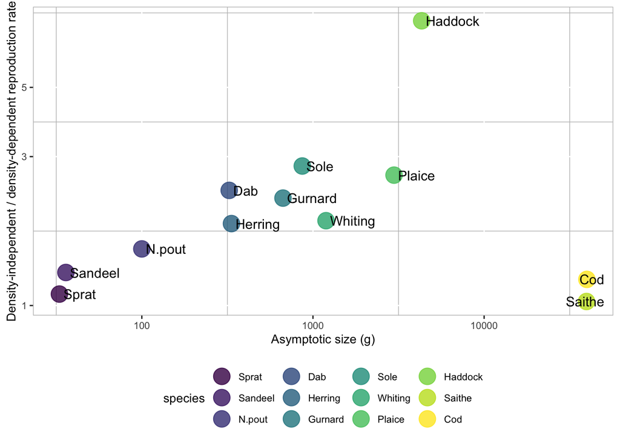

```r
plot_dat <- as.data.frame(getRDI(sim_guessed@params)/getRDD(sim_guessed@params))
plot_dat$species <- factor(rownames(plot_dat),sim_guessed@params@species_params$species)
colnames(plot_dat)[1] <- "ratio"
plot_dat$w_inf <- sim_guessed@params@species_params$w_inf

ggplot(plot_dat)+
   geom_point(aes(x = w_inf, y = ratio, color = species), size = 6, alpha = .8) +
   geom_text_repel(aes(x = w_inf, y = ratio, label = species), hjust = 0, nudge_x = 0.05)+
   scale_y_continuous(name = "Density-independent / density-dependent reproduction rate", trans = "log10") +
   scale_x_continuous(name = "Asymptotic size (g)", trans = "log10") +
   scale_colour_manual(values = sim_guessed@params@linecolour) +
   theme(panel.background = element_blank(),
         panel.border = element_rect(colour = "gray", fill=NA, size=.5),
         text = element_text(size=10),
         panel.grid.minor = element_line(color = "gray"),
         legend.position = "bottom",legend.key = element_rect(fill = "white"))
```

Is the physiological recruitment, $RDI$, much higher than the realised recruitment, $RDD$? High $RDI/RDD$ ratio indicates strong density dependence, meaning that the carrying capacity is controlling the population rather than predation or competition. Larger species often require more of this density dependent control than smaller ones. If $RDI/RDD$ is too low, the efficiency of reproduction (`erepro`) can be lowered to ensure species do not outcompete others or are over-resilient to fishing. The largest species that were the most limited by our new $R_{max}$ do not show a strong density dependence. The medium-sized species are the most affected here.

## Step 4 - Checking assumptions

In this section you will:

- Lookout for tell-tale sign of something wrong happening in your ecosystem

Let’s go through an example we have made previously to provide some tips of what to look for once you run the model.

The figure below shows an example of a calibrated ecosystem.

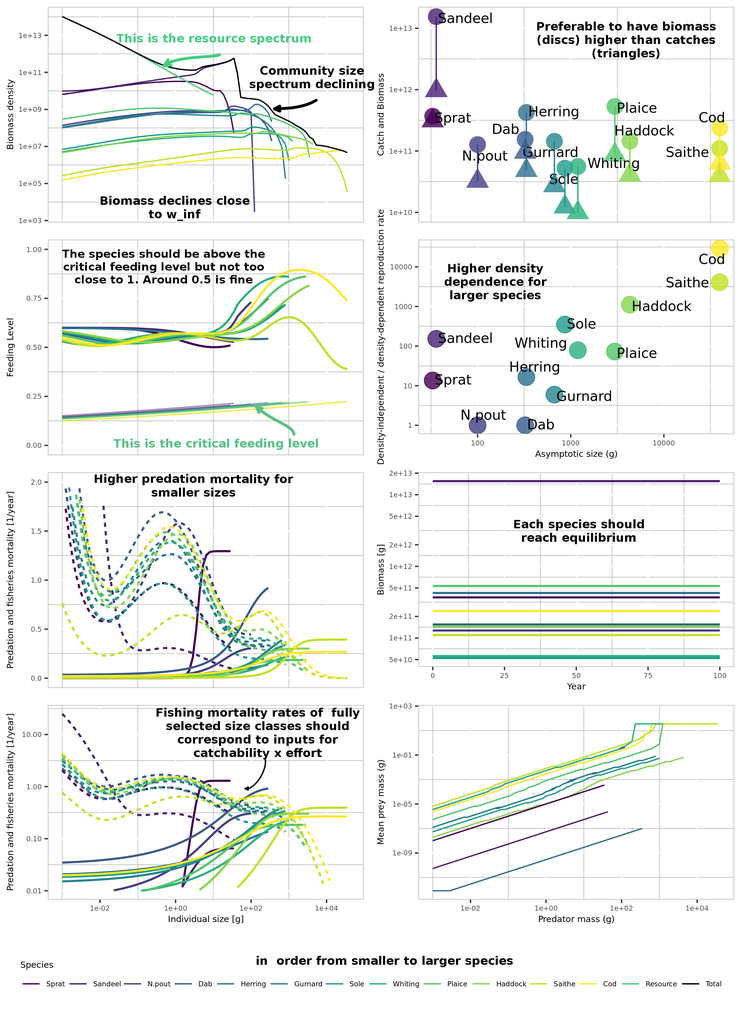

Figure 3: summary diagnostic

Let’s compare it to our own little ecosystem

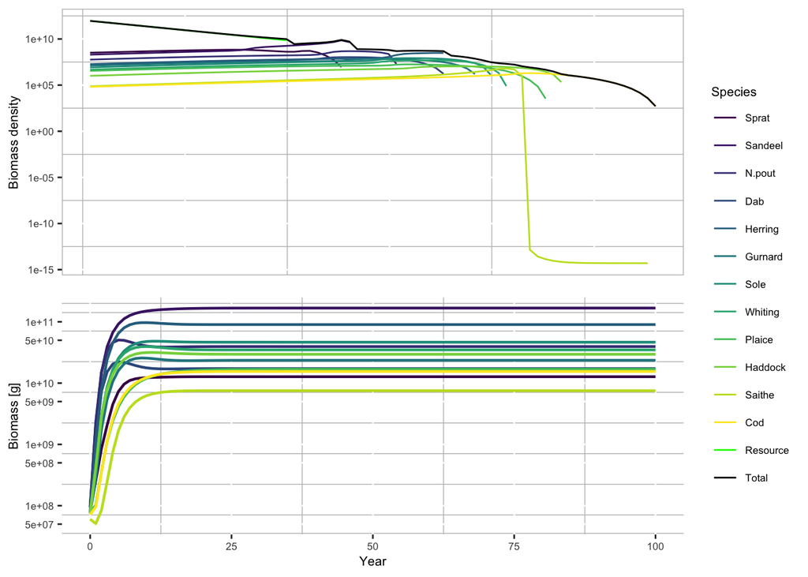

```r
plotCalibration(sim_guessed)
```